# An introduction to black-box function approximators

## [Scott Jeen](https://enjeeneer.io/)

### Xchange Seminar, 15th March 2021

## Today's Talk

- My project
- Black-box function approximation
  - **Deterministic approach**: Neural networks and Long-short term memory (LSTMs)
  - **Probabilistic approach**: Gaussian processes (GPs)
- Timeseries applications
- Key takeaways

## 1. My Project

[figure not shown]

*Video: Deepmind's Deep Q-network solving the Atari game Breakout after 600 episodes of self-play [(Mnih et. al (2013))](https://arxiv.org/pdf/1312.5602.pdf)*

[figure not shown]

*Figure: **Top:** AlphaGo's infamous Move 37, a counterintuitive move for a human to make with this board set-up, but nonetheless a gaming-winning one. **Bottom:** Lee Sedol, the world no.1 Go player, flumexed by AlphaGo's moves.*

[figure not shown]

*Figure: The complex, interconnected electricity grid*

### 1.1 Reinforcement Learning

[figure not shown]

*Figure: The RL control loop. Agent's take sequential actions that affect their environment, the environment changes and the agent receives a reward for their action. Adapted from [Episode 1 of David Silver's RL Youtube series](https://www.youtube.com/watch?v=2pWv7GOvuf0&t=1757s)*

More formally, the RL control loop looks something like this:

[figure not shown]

*Figure: The formalised RL control loop.*

## 2. Black-box Function Approximation

### 2.1 Two approaches to modelling

Generally when we model a function using a black-box approximator, we can select (informally) from two sets of models, these are:

- **Deterministic models:** Do not contain elements of randomness; everytime the model is run with the same intial conditions it produces identical results.
- **Probabilistic models:** Include elements of randomness; trials with identical initial conditions will produce different results.

### 2.2 Determinstic models

[figure not shown]

### Linear Basis

$$ f(x) = {\color{red}{w_0}} + {\color{blue}{w_1} x} $$

```python
from ipywidgets import interact
import ipywidgets as widgets

def y_linear_plot(w1, w0):

    y_lin = w1*x_true+w0
    y_err = w1*x+w0

    with plt.xkcd():
        fig = plt.figure(figsize=(10,5))
        plt.xlim([-6,6])
        plt.ylim([-4,4])
        plt.scatter(x, y, 100, 'k', 'o', zorder=100)
        plt.plot(x_true, y_lin)
        plt.vlines(x=x, ymin=y_err, ymax=y, colors='green', ls=':', lw=2)
        plt.savefig(path+'/images/2_data.png', dpi=300)
        plt.show()

interact(y_linear_plot, w1=widgets.FloatSlider(value=0.75, min=-5, max=5, step=0.25),
                    w0=widgets.FloatSlider(value=-.25, min=-5, max=5, step=0.25))
```

```
<function __main__.y_linear_plot(w1, w0)>
```

### Polynomial Basis

$$ f(x) = {\color{red}{w_0}} + {\color{blue}{w_1}} x + {\color{green}{w_2}} x^2 + {\color{orange}{w_3}} x^3 $$

```python
def y_poly_plot(w0, w1, w2, w3):

    y_poly = w0 + w1*x_true + w2*(x_true**2) + w3*(x_true**3)
    y_polyerr = w0 + w1*x + w2*(x**2) + w3*(x**3)

    with plt.xkcd():
        fig = plt.figure(figsize=(10,5))
        plt.xlim([-6,6])
        plt.ylim([-4,4])
        plt.scatter(x, y, 100, 'k', 'o', zorder=100)
        plt.plot(x_true, y_poly)
        plt.vlines(x=x, ymin=y_polyerr, ymax=y, colors='green', ls=':', lw=2)
        plt.savefig(path+'/images/3_data.png', dpi=300)
        plt.show()

interact(y_poly_plot,
             w0=widgets.FloatSlider(value=-1, min=-7, max=7, step=0.5),
             w1=widgets.FloatSlider(value=-.5, min=-7, max=7, step=0.5),
             w2=widgets.FloatSlider(value=1.5, min=-7, max=7, step=0.5),
             w3=widgets.FloatSlider(value=1, min=-7, max=7, step=0.5),
        )
```

```
<function __main__.y_poly_plot(w0, w1, w2, w3)>
```

### Rectified Linear Unit (ReLU)

$$ f(x) = \max (0 , {\color{blue}{w_1}} x + {\color{red}{w_0}}) $$

[figure not shown]

*Figure: **Top:** A neural network with 4 nodes and 1 hidden layer–a graph of the model created by hand above. **Bottom:** A neural network with 10 nodes and 2 hidden layers–a more typical model arrangement.*

[figure not shown]

## 3. Probabilistic Models: Gaussian Processes

We use [Bayes' rule](https://en.wikipedia.org/wiki/Bayes%27_theorem) to narrow the solution space, which tells us how to update our beliefs about the world based on the evidence we've seen:

$$ P (A | B) = \frac{P(B | A) P(A)}{P(B)} $$

and in the setting of functions and data it looks something like:

$$ P (\textbf{f} | \textbf{D}) = \frac{P(\textbf{D} | \textbf{f}) P(\textbf{f})}{P(\textbf{D})} $$

[figure not shown]

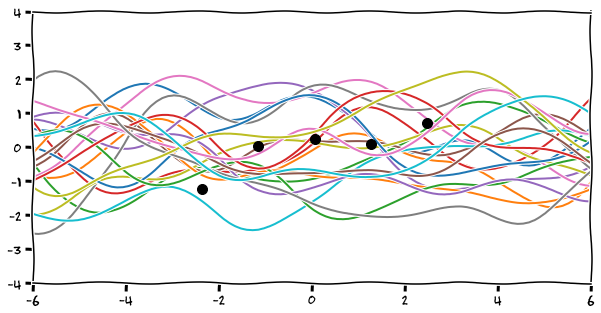

```python
# plot rbf kernel
with plt.xkcd():
    fig = plt.figure(figsize=(10,5))
    plt.scatter(x, y, 100, 'k', 'o', zorder=100)
    plt.plot(x_true, f_rbf.T)
    plt.xlim([-6,6])
    plt.ylim([-4,4])
    plt.savefig(path+'/images/8_data.png', dpi=300)
    plt.show()
```

### 3.1 Prior Beliefs

[figure not shown]

### 3.2 (Different) Prior Beliefs

[figure not shown]

### 3.3 Drawbacks

- Expensive to compute; N > ~50,000 prohibitively large
- Prior knowledge remains crucial

## 4. Timeseries applications

[figure not shown]

## 5. Key Takeaways

- Black box function approximators can model *any* continuous function in theory
- Deterministic techniques effective with large (N > $10^5$) datasets
- Probabilistic techniques more robust in low data regimes thanks to uncertainty quantification
- GPs are limited by their expensive computations (N must be < $10^5$)
- Both approaches can be used to model complex timeseries datasets

## Further Reading

**Further explanations on why these techniques work**

- [Can neural networks solve any problem?](https://towardsdatascience.com/can-neural-networks-really-learn-any-function-65e106617fc6)
- [Visualising how LSTMs make predictions](https://distill.pub/2019/memorization-in-rnns/)

**How can you build these in practice?**

- Neural nets: [Introduction to deep learning with tensorflow](https://machinelearningmastery.com/tensorflow-tutorial-deep-learning-with-tf-keras/)
- GPs: [GP regression on molecules](https://towardsdatascience.com/gaussian-process-regression-on-molecules-in-gpflow-ee6fedab2130)
- LSTMs: [LSTMs for timeseries prediction](https://towardsdatascience.com/lstm-for-time-series-prediction-de8aeb26f2ca)

**Introductory Books**

- [The art of statistics: how to learn from data - David Spiegelhalter (2018)](https://www.amazon.co.uk/Art-Statistics-Learning-Pelican-Books/dp/0241398630)
- [Life 3.0: Being Human in the Age of Artificial Intelligence - Max Tegmark (2017)](https://www.amazon.co.uk/dp/B07474JB3Q/ref=dp-kindle-redirect?_encoding=UTF8&btkr=1)

# Thanks!

- Notes: https://enjeeneer.io/cv/cv.pft
- Thanks to [Carl Henrik Ek](http://carlhenrik.com/), Dept. of Computer Science for inspiring these slides
- Questions?